# MP_SRF_18S_amplicons_tax

lrubinat

05/03/2016

# 1) 18S amplicons

Data uploading:

```
## [1] 47144   132
```

```
##   OTUId st001 st002 st003 st004
## 1 OTU_1   469   187   240   135
## 2 OTU_2   445   389   760   819
## 3 OTU_3  1030  2196  1611   453
## 4 OTU_4   135    66    36   365
## 5 OTU_5     0   178   285   175
```

```
## [1] 47144   131
```

```
##       st001 st002 st003 st004 st005
## OTU_1   469   187   240   135   184
## OTU_2   445   389   760   819  1003
## OTU_3  1030  2196  1611   453   512
## OTU_4   135    66    36   365   146
## OTU_5     0   178   285   175    49
```

```
## [1] 47144     7
```

```
##                                                                                                                          SILVA_taxonomic_classification
## OTU_1         KC488417.1.1688_Eukaryota;SAR;Alveolata;Dinoflagellata;Dinophyceae;Gymnodiniphycidae;Gymnodinium_clade;FV18-2D9;uncultured_dinoflagellate
## OTU_2                              FJ832119.1.1585_Eukaryota;SAR;Alveolata;Protalveolata;Syndiniales;Syndiniales_Group_I;uncultured_marine_picoplankton
## OTU_3                                       EF172960.1.1674_Eukaryota;SAR;Alveolata;Protalveolata;Syndiniales;Syndiniales_Group_II;uncultured_eukaryote
## OTU_4 KC488405.1.1558_Eukaryota;SAR;Alveolata;Dinoflagellata;Dinophyceae;Gymnodiniphycidae;Gymnodinium_clade;Erythropsidinium;uncultured_dinoflagellate
## OTU_5                                      EU793901.1.1663_Eukaryota;SAR;Alveolata;Protalveolata;Syndiniales;Syndiniales_Group_I;uncultured_syndiniales
##         MAS_taxonomic_classification   BM_taxonomic_classification
## OTU_1 EU793855_Dinophyceae_Alveolata 9492_Dinophyceae_Alveolata_15
## OTU_2      EU793773_MALV-I_Alveolata     3261_MALV-I_Alveolata_385
## OTU_3     EU793316_MALV-II_Alveolata                          <NA>
## OTU_4 EU780636_Dinophyceae_Alveolata 21474_Dinophyceae_Alveolata_6
## OTU_5      EU818388_MALV-I_Alveolata      398_MALV-I_Alveolata_395
##       SILVA_class   MAS_class    BM_class MAS_plus_BM_plus_SILVA_class
## OTU_1 Dinophyceae Dinophyceae Dinophyceae                  Dinophyceae
## OTU_2        <NA>        <NA>        <NA>                         <NA>
## OTU_3        <NA>        <NA>        <NA>                         <NA>
## OTU_4 Dinophyceae Dinophyceae Dinophyceae                  Dinophyceae
## OTU_5        <NA>        <NA>        <NA>                         <NA>
```

```
## [1] 47144   124
```

```
##       st001 st002 st003 st004 st005
## OTU_1   469   187   240   135   184
## OTU_2   445   389   760   819  1003
## OTU_3  1030  2196  1611   453   512
## OTU_4   135    66    36   365   146
## OTU_5     0   178   285   175    49
```

```
## st054
##  4050
```

```
## [1] 47144   123
```

Table dimensions and content outline:

```
## [1] 47144   123
```

```
##       st001 st002 st003 st004 st005
## OTU_1   469   187   240   135   184
## OTU_2   445   389   760   819  1003
## OTU_3  1030  2196  1611   453   512
## OTU_4   135    66    36   365   146
## OTU_5     0   178   285   175    49
```

Minimum number of reads per station:

```r
min(colSums(tb18_tax_occur_min8522))
```

```
## [1] 8522
```

Maximum number of reads per station:

```r
max(colSums(tb18_tax_occur_min8522))
```

```
## [1] 936570
```

Identification of station with higher number of reads:

```r
amplicons_per_sample<-colSums(tb18_tax_occur_min8522)
amplicons_per_sample[which(colSums(tb18_tax_occur_min8522)>900000)]
```

```
##  st131
## 936570
```

Overall reads per sample:

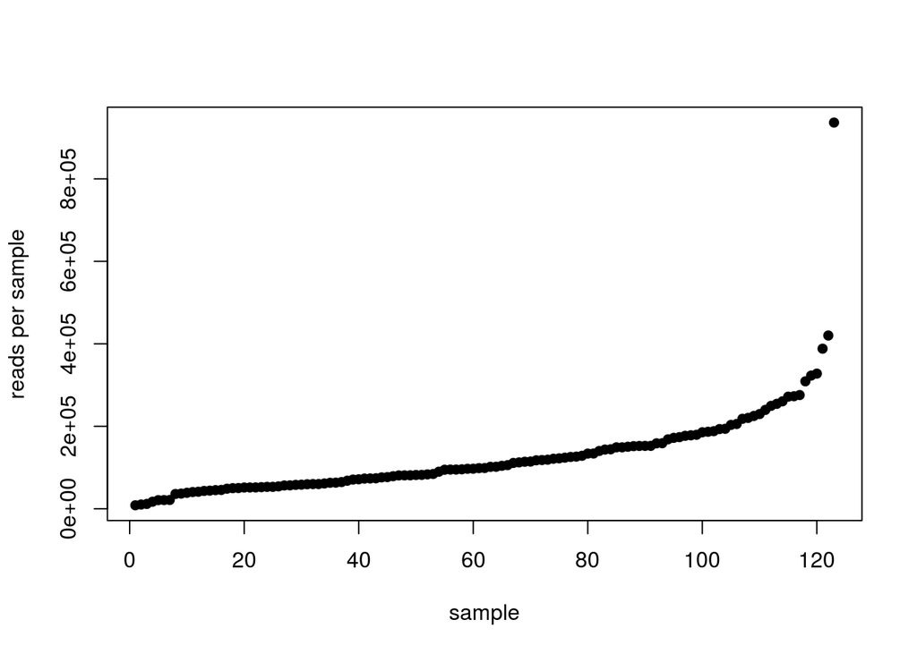

## 2) Normalization

Let’s normalize the original dataset by randomly subsampling 8522 reads in each station:

```r
library(vegan)
tb18_tax_occur_min8522_t<-t(tb18_tax_occur_min8522)
tb18_tax_occur_ss8522<-rrarefy(tb18_tax_occur_min8522_t, 8522)
```

The normalized table shows the following dimensions and format:

```
## [1]   123 47144
```

```
##       OTU_1 OTU_2 OTU_3 OTU_4 OTU_5
## st001    15    15    44     6     0
## st002    22    33   255     6    22
## st003    34   141   284     7    48
## st004    28   182   105    81    44
## st005    23   118    74    29     8
```

Its content fits with the expected normalization values (8522 reads per station):

```r
rowSums(tb18_tax_occur_ss8522)
```

```
##   st001   st002   st003   st004   st005   st007   st009   st010   st012
##    8522    8522    8522    8522    8522    8522    8522    8522    8522
##   st013   st014   st015   st017   st018   st019   st022   st023   st024
##    8522    8522    8522    8522    8522    8522    8522    8522    8522
##   st025   st026   st027   st028   st029   st030   st032   st033   st034
##    8522    8522    8522    8522    8522    8522    8522    8522    8522
##   st035   st037   st038   st039   st040   st041   st043   st044   st045
##    8522    8522    8522    8522    8522    8522    8522    8522    8522
##   st046   st047   st049   st050   st051   st052   st053   st055   st056
##    8522    8522    8522    8522    8522    8522    8522    8522    8522
##   st057   st058   st059   st060   st062   st063   st064   st065   st066
##    8522    8522    8522    8522    8522    8522    8522    8522    8522
##   st067   st068 st068.1   st069   st070   st071 st071.1   st072   st073
##    8522    8522    8522    8522    8522    8522    8522    8522    8522
##   st074   st075   st076   st077   st078   st079   st081   st082   st083
##    8522    8522    8522    8522    8522    8522    8522    8522    8522
##   st085   st086   st087   st088   st089   st092   st093   st094   st095
##    8522    8522    8522    8522    8522    8522    8522    8522    8522
##   st096   st097   st098   st101   st102   st103   st104   st106   st107
##    8522    8522    8522    8522    8522    8522    8522    8522    8522
##   st108   st109   st110   st112   st114   st115   st116   st118   st119
##    8522    8522    8522    8522    8522    8522    8522    8522    8522
##   st120   st121   st122   st124   st125   st126   st127   st128   st129
##    8522    8522    8522    8522    8522    8522    8522    8522    8522
##   st130   st131   st132   st133   st134   st135   st137   st138   st139
##    8522    8522    8522    8522    8522    8522    8522    8522    8522
##   st140   st141   st143   st144   st145   st146
##    8522    8522    8522    8522    8522    8522
```

Let’s check out how many OTUs don’t appear in the new table:

```r
length(which(colSums(tb18_tax_occur_ss8522)==0))
```

```
## [1] 20110
```

```r
tb18_tax_occur_ss8522_no_cero<-tb18_tax_occur_ss8522[,-(which(colSums(tb18_tax_occur_ss8522)==0))]
dim(tb18_tax_occur_ss8522_no_cero)
```

```
## [1]   123 27034
```

Let’s add the taxonomic classification to the left OTUs by merging “tb18_tax_occur_ss8522_no_cero” with “tb18_tax”.

```
## [1] 27034   131
```

```
##   Row.names st001 st002 st003 st004
## 1     OTU_1    15    22    34    28
## 2    OTU_10     0     5    36    43
## 3   OTU_100    17    47     1     7
## 4  OTU_1000     0     0     1     3
## 5 OTU_10000     0     1     0     0
```

```
## [1] 27034   130
```

```
##           st001 st002 st003 st004 st005
## OTU_1        15    22    34    28    23
## OTU_10        0     5    36    43    18
## OTU_100      17    47     1     7     9
## OTU_1000      0     0     1     3     0
## OTU_10000     0     1     0     0     0
```

```
## [1] 27034   131
```

```
##       st001 st002 st003 st004 st005
## OTU_1    15    22    34    28    23
## OTU_2    15    33   141   182   118
## OTU_3    44   255   284   105    74
## OTU_4     6     6     7    81    29
## OTU_5     0    22    48    44     8
```

```
## [1] 7802  131
```

```
## [1] 243  82   0  74   0
```

```
##               Group.1      x
## 9         Dinophyceae 144144
## 14     Prasinophyceae  21178
## 5       Chrysophyceae  17346
## 12      Pelagophyceae  10609
## 8    Dictyochophyceae   8729
## 6     Cryptomonadales   2181
## 7            Diatomea    878
## 3  Chlorarachniophyta    755
## 2         Bolidomonas    613
## 13  Pinguiochysidales    303
## 15   Prymnesiophyceae     78
## 11    Mamiellophyceae     77
## 16     Raphydophyceae     54
## 4       Chlorophyceae     51
## 10      Eustigmatales     48
## 18        Ulvophyceae     33
## 17   Trebouxiophyceae     27
## 1                         12
```

```
##               Group.1    x
## 9         Dinophyceae 6520
## 14     Prasinophyceae  298
## 5       Chrysophyceae  255
## 12      Pelagophyceae  225
## 8    Dictyochophyceae  169
## 7            Diatomea   76
## 6     Cryptomonadales   58
## 3  Chlorarachniophyta   56
## 15   Prymnesiophyceae   31
## 11    Mamiellophyceae   26
## 4       Chlorophyceae   23
## 2         Bolidomonas   16
## 18        Ulvophyceae   16
## 13  Pinguiochysidales   14
## 17   Trebouxiophyceae    8
## 10      Eustigmatales    7
## 16     Raphydophyceae    3
## 1                        1
```

# 2) 16S amplicons

# 1) Data overview

```
## [1] 993 130
```

```
##   OTUId st001 st002 st003 st004
## 1 OTU_1 72073 45381 40792 26317
## 2 OTU_2 11925 13467  6500  4802
## 3 OTU_3    19    12    10    21
## 4 OTU_4  1795  2861  1057   993
## 5 OTU_5  1766  1341   463   499
```

```
## [1] 993 129
```

```
##       st001 st002 st003 st004 st005
## OTU_1 72073 45381 40792 26317 65068
## OTU_2 11925 13467  6500  4802 10947
## OTU_3    19    12    10    21     4
## OTU_4  1795  2861  1057   993  2466
## OTU_5  1766  1341   463   499  1912
```

```
## [1] 993   5
```

```
##                                                                                                        SILVA_taxonomic_classification
## OTU_1   KC002097.1.1314_Bacteria;Cyanobacteria;Cyanobacteria;SubsectionI;FamilyI;Prochlorococcus;unidentified_marine_bacterioplankton
## OTU_2                          EU800388.1.1465_Bacteria;Proteobacteria;Alphaproteobacteria;SAR11_clade;Surface_1;uncultured_bacterium
## OTU_3 KJ590614.1.1421_Bacteria;Proteobacteria;Alphaproteobacteria;Rhodobacterales;Rhodobacteraceae;Sulfitobacter;uncultured_bacterium
## OTU_4  EU805005.1.1343_Bacteria;Actinobacteria;Acidimicrobiia;Acidimicrobiales;OM1_clade;Candidatus_Actinomarina;uncultured_bacterium
## OTU_5     KC000519.1.1314_Bacteria;Cyanobacteria;Cyanobacteria;SubsectionI;FamilyI;Synechococcus;unidentified_marine_bacterioplankton
##                                                                                                Phytoref_taxonomic_classification
## OTU_1   EU803052.1.1425|Bacteria|Cyanobacteria|Cyanobacteria|SubsectionI|FamilyI|Prochlorococcus|uncultured|uncultured+bacterium
## OTU_2                                                                                                                       <NA>
## OTU_3                                                                                                                       <NA>
## OTU_4                                                                                                                       <NA>
## OTU_5 AY663935.1.1244|Bacteria|Cyanobacteria|Cyanobacteria|SubsectionI|FamilyI|Synechococcus|uncultured|uncultured+Synechococcus
##       SILVA_funct_classif Phytoref_funct_classif taxonomic_classes
## OTU_1              cyanob                 cyanob   Prochlorococcus
## OTU_2            bacteria                   <NA>          bacteria
## OTU_3            bacteria                   <NA>          bacteria
## OTU_4            bacteria                   <NA>          bacteria
## OTU_5              cyanob                 cyanob     Synechococcus
```

```
## [1] 993 124
```

```
##       st001 st002 st003 st004 st005
## OTU_1 72073 45381 40792 26317 65068
## OTU_2 11925 13467  6500  4802 10947
## OTU_3    19    12    10    21     4
## OTU_4  1795  2861  1057   993  2466
## OTU_5  1766  1341   463   499  1912
```

```
## st122 st124 st137 st144
##  2736  3439   421   626
```

```
## [1] 993 120
```

```
## [1] 993 119
```

Table dimensions and content outline:

```
## [1] 993 119
```

```
##       st001 st002 st003 st004 st005
## OTU_1 72073 45381 40792 26317 65068
## OTU_2 11925 13467  6500  4802 10947
## OTU_3    19    12    10    21     4
## OTU_4  1795  2861  1057   993  2466
## OTU_5  1766  1341   463   499  1912
```

Minimum number of reads per station:

```r
min(colSums(tb16_tax_occur_min5844))
```

```
## [1] 5844
```

Maximum number of reads per station:

```r
max(colSums(tb16_tax_occur_min5844))
```

```
## [1] 156413
```

Identification of station with higher number of reads:

```r
amplicons_per_sample<-colSums(tb16_tax_occur_min5844)
amplicons_per_sample[which(colSums(tb16_tax_occur_min5844)>150000)]
```

```
##  st050
## 156413
```

Overall reads per sample:

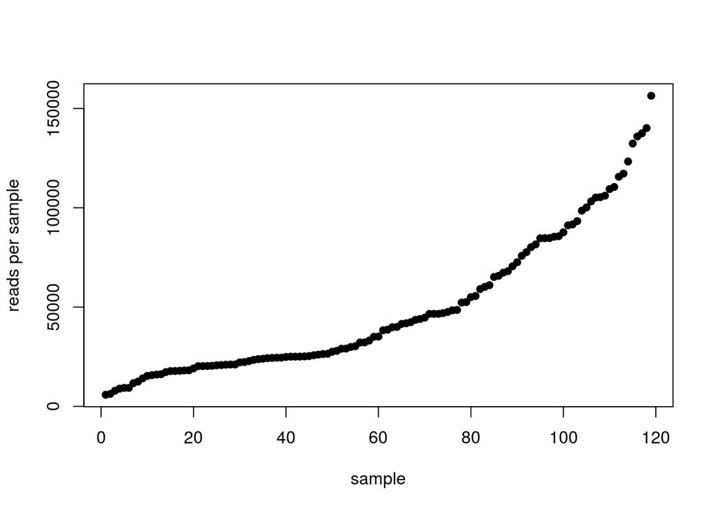

## 2) Normalization

Let’s normalize the original dataset by randomly subsampling 5844 reads in each station:

```r
library(vegan)
tb16_tax_occur_min5844_t<-t(tb16_tax_occur_min5844)
tb16_tax_occur_ss5844<-rrarefy(tb16_tax_occur_min5844_t, 5844)
```

The normalized table shows the following dimensions and format:

```
## [1] 119 993
```

```
##       OTU_1 OTU_2 OTU_3 OTU_4 OTU_5
## st001  4027   643     3    93   114
## st002  3267   994     0   210   100
## st003  4349   662     0   102    41
## st004  3794   716     5   157    66
## st005  4160   716     1   164   130
```

Its content fits with the expected normalization values (5844 reads per station):

```r
rowSums(tb16_tax_occur_ss5844)
```

```
##   st001   st002   st003   st004   st005   st007   st009   st010   st012
##    5844    5844    5844    5844    5844    5844    5844    5844    5844
##   st013   st014   st015   st017   st018   st019   st022   st023   st024
##    5844    5844    5844    5844    5844    5844    5844    5844    5844
##   st025   st026   st027   st028   st029   st030   st032   st033   st034
##    5844    5844    5844    5844    5844    5844    5844    5844    5844
##   st035   st037   st038   st039   st040   st041   st043   st044   st045
##    5844    5844    5844    5844    5844    5844    5844    5844    5844
##   st046   st047   st049   st050   st051   st052   st053   st055   st056
##    5844    5844    5844    5844    5844    5844    5844    5844    5844
##   st057   st058   st059   st060   st062   st063   st064   st065   st066
##    5844    5844    5844    5844    5844    5844    5844    5844    5844
##   st067   st068 st068.1   st069   st070   st071 st071.1   st072   st073
##    5844    5844    5844    5844    5844    5844    5844    5844    5844
##   st074   st075   st076   st077   st078   st079   st081   st082   st083
##    5844    5844    5844    5844    5844    5844    5844    5844    5844
##   st085   st086   st087   st088   st089   st092   st093   st094   st095
##    5844    5844    5844    5844    5844    5844    5844    5844    5844
##   st096   st097   st098   st101   st102   st103   st104   st106   st107
##    5844    5844    5844    5844    5844    5844    5844    5844    5844
##   st108   st109   st110   st112   st114   st115   st116   st118   st119
##    5844    5844    5844    5844    5844    5844    5844    5844    5844
##   st120   st121   st125   st126   st127   st128   st129   st130   st131
##    5844    5844    5844    5844    5844    5844    5844    5844    5844
##   st132   st133   st134   st135   st138   st139   st140   st141   st143
##    5844    5844    5844    5844    5844    5844    5844    5844    5844
##   st145   st146
##    5844    5844
```

Let’s check out how many OTUs don’t appear in the new table:

```r
length(which(colSums(tb16_tax_occur_ss5844)==0))
```

```
## [1] 40
```

```r
tb16_tax_occur_ss5844_no_cero<-tb16_tax_occur_ss5844[,-(which(colSums(tb16_tax_occur_ss5844)==0))]
dim(tb16_tax_occur_ss5844_no_cero)
```

```
## [1] 119 953
```

Let’s add the taxonomic classification to the left OTUs by merging “tb16_tax_occur_ss5844_no_cero” with “tb16_tax”.

```
## [1] 953 125
```

```
##   Row.names st001 st002 st003 st004
## 1     OTU_1  4027  3267  4349  3794
## 2    OTU_10    17    36    13    31
## 3   OTU_100     0     0     0     0
## 4  OTU_1001     0     0     0     0
## 5  OTU_1004     0     0     0     0
```

```
##   st001   st002   st003   st004   st005   st007   st009   st010   st012
##    5844    5844    5844    5844    5844    5844    5844    5844    5844
##   st013   st014   st015   st017   st018   st019   st022   st023   st024
##    5844    5844    5844    5844    5844    5844    5844    5844    5844
##   st025   st026   st027   st028   st029   st030   st032   st033   st034
##    5844    5844    5844    5844    5844    5844    5844    5844    5844
##   st035   st037   st038   st039   st040   st041   st043   st044   st045
##    5844    5844    5844    5844    5844    5844    5844    5844    5844
##   st046   st047   st049   st050   st051   st052   st053   st055   st056
##    5844    5844    5844    5844    5844    5844    5844    5844    5844
##   st057   st058   st059   st060   st062   st063   st064   st065   st066
##    5844    5844    5844    5844    5844    5844    5844    5844    5844
##   st067   st068 st068.1   st069   st070   st071 st071.1   st072   st073
##    5844    5844    5844    5844    5844    5844    5844    5844    5844
##   st074   st075   st076   st077   st078   st079   st081   st082   st083
##    5844    5844    5844    5844    5844    5844    5844    5844    5844
##   st085   st086   st087   st088   st089   st092   st093   st094   st095
##    5844    5844    5844    5844    5844    5844    5844    5844    5844
##   st096   st097   st098   st101   st102   st103   st104   st106   st107
##    5844    5844    5844    5844    5844    5844    5844    5844    5844
##   st108   st109   st110   st112   st114   st115   st116   st118   st119
##    5844    5844    5844    5844    5844    5844    5844    5844    5844
##   st120   st121   st125   st126   st127   st128   st129   st130   st131
##    5844    5844    5844    5844    5844    5844    5844    5844    5844
##   st132   st133   st134   st135   st138   st139   st140   st141   st143
##    5844    5844    5844    5844    5844    5844    5844    5844    5844
##   st145   st146
##    5844    5844
```

```
## [1] 953 124
```

```
##          st001 st002 st003 st004 st005
## OTU_1     4027  3267  4349  3794  4160
## OTU_10      17    36    13    31     7
## OTU_100      0     0     0     0     0
## OTU_1001     0     0     0     0     0
## OTU_1004     0     0     0     0     0
```

```
## [1] 953 125
```

```
##       taxonomic_classes OTU_no
## OTU_1   Prochlorococcus      1
## OTU_2          bacteria      2
## OTU_3          bacteria      3
## OTU_4          bacteria      4
## OTU_5     Synechococcus      5
```

```
## [1]  85 125
```

```
## [1] 868 125
```

```
##         st146
## OTU_54      2
## OTU_57     18
## OTU_58      1
## OTU_80      0
## OTU_114     0
##                                                                SILVA_taxonomic_classification
## OTU_54                EU237456.1.1310_Bacteria;Cyanobacteria;Chloroplast;uncultured_bacterium
## OTU_57   AY664138.1.1204_Bacteria;Cyanobacteria;Chloroplast;uncultured_phototrophic_eukaryote
## OTU_58                                                                                   <NA>
## OTU_80  HM565911.2962.4423_Bacteria;Cyanobacteria;Chloroplast;uncultured_prymnesiophyte_C8704
## OTU_114               JN986350.1.1460_Bacteria;Cyanobacteria;Chloroplast;uncultured_bacterium
##                                                                                                                                                              Phytoref_taxonomic_classification
## OTU_54  5523_AB847984|Eukaryota|Hacrobia|Haptophyta|Prymnesiophyceae|Prymnesiophyceae_X|Prymnesiophyceae_XX|Prymnesiophyceae_XXX|Braarudosphaeraceae|Braarudosphaera|Braarudosphaera_bigelowii
## OTU_57            474_Eukaryota|Stramenopiles|Ochrophyta|Dictyochophyceae|Dictyochophyceae_X|Dictyochophyceae_XX|Dictyochophyceae_XXX|Dictyochophyceae_XXXX|Helicopedinella|Helicopedinella_sp
## OTU_58       432_DQ438491|Eukaryota|Archaeplastida|Chlorophyta|Prasinophyceae|Prasinophyceae_X|Prasino-clade-9|Prasino-clade-9_X|Prasino-clade-9_XX|Prasino-clade-9_XXX|Prasino-clade-9_XXX_sp
## OTU_80                                                                                                                                                                                    <NA>
## OTU_114   891_FJ649309|Eukaryota|Archaeplastida|Chlorophyta|Prasinophyceae|Prasinophyceae_X|Prasino-clade-7|Prasino-clade-7_X|Prasino-clade-7_X-B|Prasino-clade-7_X-B1|Prasino-clade-7_X-B1_sp
##         SILVA_funct_classif Phytoref_funct_classif taxonomic_classes
## OTU_54              plastid                plastid  Prymnesiophyceae
## OTU_57              plastid                plastid  Dictyochophyceae
## OTU_58                 <NA>                plastid    Prasinophyceae
## OTU_80              plastid                   <NA>    other_plastids
## OTU_114             plastid                plastid    Prasinophyceae
##         OTU_no
## OTU_54      54
## OTU_57      57
## OTU_58      58
## OTU_80      80
## OTU_114    114
```

```
##       taxonomic_classes OTU_no
## OTU_1   Prochlorococcus      1
## OTU_2          bacteria      2
## OTU_3          bacteria      3
## OTU_4          bacteria      4
## OTU_5     Synechococcus      5
```

```r
class_summary_reads_per_class_16S<-aggregate(rowSums(tb16_protists[1:119]), list(tb16_protists$taxonomic_classes), sum)
# count the different groups

class_summary_otus_per_class_16S<-aggregate(rowSums(tb16_protists[1:119]), list(tb16_protists$taxonomic_classes), length)

attach(class_summary_reads_per_class_16S)
class_summary_reads_per_class_16S_order<-class_summary_reads_per_class_16S[order(-x),]
detach(class_summary_reads_per_class_16S)
class_summary_reads_per_class_16S_order
```

```
##                 Group.1    x
## 11     Prymnesiophyceae 4259
## 8        other_plastids 2049
## 6      Dictyochophyceae 1106
## 10       Prasinophyceae  916
## 7       Mamiellophyceae  333
## 9         Pelagophyceae   77
## 1       Bacillariophyta   42
## 2         Bolidophyceae   40
## 5         Cryptophyceae   23
## 12           Rappemonad   14
## 3  Chlorarachniophyceae    5
## 4         Chrysophyceae    3
```

```r
attach(class_summary_otus_per_class_16S)
class_summary_otus_per_class_16S_order<-class_summary_otus_per_class_16S[order(-x),]
detach(class_summary_otus_per_class_16S)
class_summary_otus_per_class_16S_order
```

```
##                 Group.1  x
## 8        other_plastids 28
## 11     Prymnesiophyceae 27
## 10       Prasinophyceae 10
## 6      Dictyochophyceae  7
## 7       Mamiellophyceae  4
## 1       Bacillariophyta  3
## 2         Bolidophyceae  1
## 3  Chlorarachniophyceae  1
## 4         Chrysophyceae  1
## 5         Cryptophyceae  1
## 9         Pelagophyceae  1
## 12           Rappemonad  1
```

```r
#class_summary_reads<-aggregate(sum~class, data=otutab_full_wTax, FUN="sum")
# sum reads different groups
```